# Assignment7-ARIMA

Sumin Oh

2024-11-21

#### 1. Perform ARIMA on your time series. Explain the output.

```r
library(readr)
library(forecast)
library(fpp2)
```

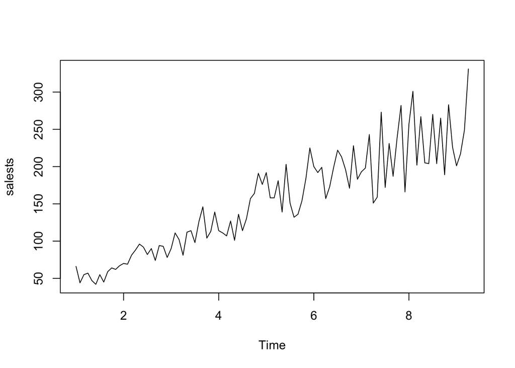

```r
# Import the data
sales = read.csv("https://raw.github.com/su-min-oh/Assignment_ARIMA/main/time%20series%20data.csv")

# Make the data time series
salests = ts(sales$ProductP2, frequency = 12)

# Plot the time series data
plot(salests)
```

My data is about the sales of 5 products and corresponding temperature. Since I did regression of Product 2 and Temperature on the last assignment, I chose Product 2 to be a time series for this ARIMA assignment. Sales is showing upward trend, with some ups and downs.

```r
decompose(salests)
```

```
## $x
##   Jan Feb Mar Apr May Jun Jul Aug Sep Oct Nov Dec
## 1  66  44  55  57  47  42  55  45  59  64  62  67
## 2  70  69  81  88  96  92  82  90  74  94  93  78
## 3  90 111 102  81 112 114  98 126 146 104 113 139
## 4 114 111 107 127 101 136 114 130 157 164 191 176
## 5 192 158 158 181 139 203 151 132 136 154 184 225
## 6 200 192 199 157 173 199 222 213 196 171 228 183
## 7 193 198 243 151 159 273 172 231 187 238 282 166
## 8 257 301 202 267 205 204 270 204 265 189 283 226
## 9 201 217 249 331
##
## $seasonal
##           Jan         Feb         Mar         Apr         May         Jun
## 1   8.1422371   9.3446181   0.3148562  -7.3696677 -19.0006200  12.4517609
```

[output cut: 72 more lines]

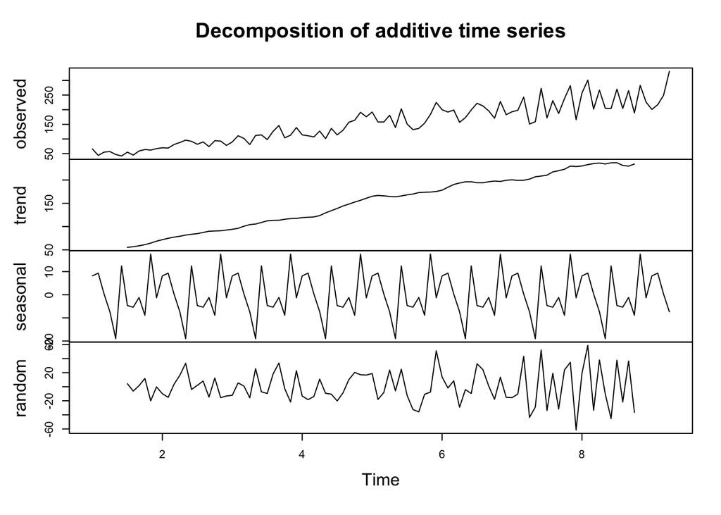

```r
plot(decompose(salests))
```

I chose to conduct decomposition of my time series. It seems that there is a seasonality.

```r
ndiffs(salests)
```

```
## [1] 1
```

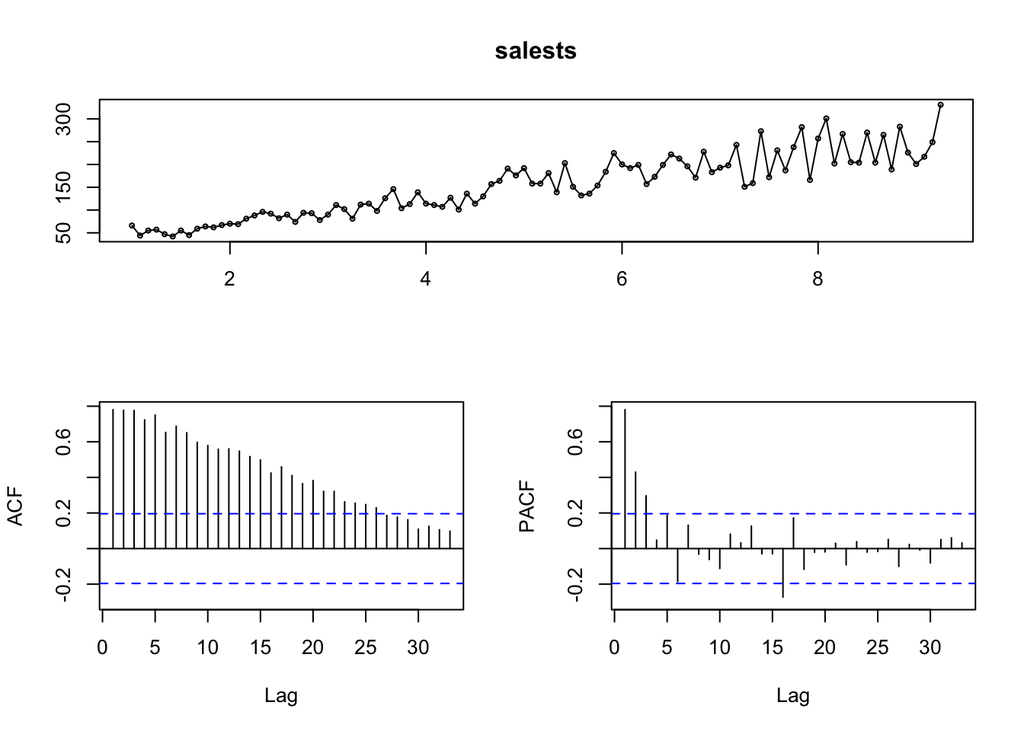

```r
tsdisplay(salests)
```

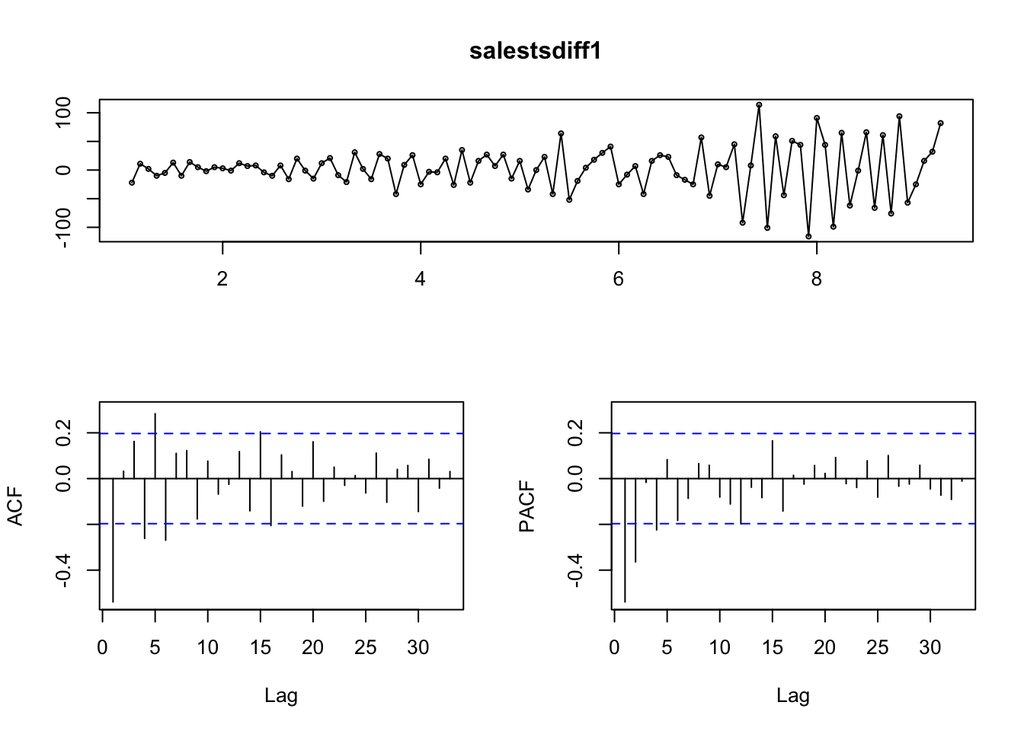

```r
salestsdiff1 = diff(salests,differences = 1)
tsdisplay(salestsdiff1)
```

```r
autofit <- auto.arima(salests, trace=TRUE, stepwise = FALSE)
```

```
##
##  ARIMA(0,1,0)                               : 1015.829
##  ARIMA(0,1,0)            with drift         : 1017.48
##  ARIMA(0,1,0)(0,0,1)[12]                    : 1017.863
##  ARIMA(0,1,0)(0,0,1)[12] with drift         : 1019.537
##  ARIMA(0,1,0)(0,0,2)[12]                    : 1019.937
##  ARIMA(0,1,0)(0,0,2)[12] with drift         : 1021.665
##  ARIMA(0,1,0)(1,0,0)[12]                    : 1017.861
##  ARIMA(0,1,0)(1,0,0)[12] with drift         : 1019.534
##  ARIMA(0,1,0)(1,0,1)[12]                    : 1019.984
##  ARIMA(0,1,0)(1,0,1)[12] with drift         : 1021.702
##  ARIMA(0,1,0)(1,0,2)[12]                    : 1021.859
##  ARIMA(0,1,0)(1,0,2)[12] with drift         : 1023.678
##  ARIMA(0,1,0)(2,0,0)[12]                    : 1019.941
##  ARIMA(0,1,0)(2,0,0)[12] with drift         : 1021.671
##  ARIMA(0,1,0)(2,0,1)[12]                    : Inf
##  ARIMA(0,1,0)(2,0,1)[12] with drift         : Inf
##  ARIMA(0,1,0)(2,0,2)[12]                    : Inf
##  ARIMA(0,1,0)(2,0,2)[12] with drift         : Inf
##  ARIMA(0,1,1)                               : 965.9992
##  ARIMA(0,1,1)            with drift         : Inf
##  ARIMA(0,1,1)(0,0,1)[12]                    : 967.5319
##  ARIMA(0,1,1)(0,0,1)[12] with drift         : Inf
##  ARIMA(0,1,1)(0,0,2)[12]                    : 969.6905
##  ARIMA(0,1,1)(0,0,2)[12] with drift         : Inf
##  ARIMA(0,1,1)(1,0,0)[12]                    : 967.513
##  ARIMA(0,1,1)(1,0,0)[12] with drift         : Inf
##  ARIMA(0,1,1)(1,0,1)[12]                    : Inf
##  ARIMA(0,1,1)(1,0,1)[12] with drift         : Inf
##  ARIMA(0,1,1)(1,0,2)[12]                    : Inf
##  ARIMA(0,1,1)(1,0,2)[12] with drift         : Inf
##  ARIMA(0,1,1)(2,0,0)[12]                    : 969.6464
##  ARIMA(0,1,1)(2,0,0)[12] with drift         : Inf
##  ARIMA(0,1,1)(2,0,1)[12]                    : Inf
##  ARIMA(0,1,1)(2,0,1)[12] with drift         : Inf
##  ARIMA(0,1,1)(2,0,2)[12]                    : Inf
##  ARIMA(0,1,1)(2,0,2)[12] with drift         : Inf
##  ARIMA(0,1,2)                               : 964.8565
##  ARIMA(0,1,2)            with drift         : Inf
##  ARIMA(0,1,2)(0,0,1)[12]                    : 966.4015
```

[output cut: 142 more lines]

```
##  ARIMA(3,1,2)            with drift         : Inf
##  ARIMA(4,1,0)                               : 964.1869
##  ARIMA(4,1,0)            with drift         : 961.0157
##  ARIMA(4,1,0)(0,0,1)[12]                    : 966.3955
##  ARIMA(4,1,0)(0,0,1)[12] with drift         : 963.2155
##  ARIMA(4,1,0)(1,0,0)[12]                    : 966.3934
##  ARIMA(4,1,0)(1,0,0)[12] with drift         : 963.223
##  ARIMA(4,1,1)                               : 962.5574
##  ARIMA(4,1,1)            with drift         : Inf
##  ARIMA(5,1,0)                               : 965.1345
##  ARIMA(5,1,0)            with drift         : 962.9027
##
##
##
##  Best model: ARIMA(2,1,2)
```

```r
autofit
```

```
## Series: salests
## ARIMA(2,1,2)
##
## Coefficients:
##           ar1      ar2     ma1      ma2
##       -1.1718  -0.3682  0.3549  -0.5993
## s.e.   0.1224   0.1280  0.1109   0.1136
##
## sigma^2 = 867:  log likelihood = -474.37
## AIC=958.75   AICc=959.39   BIC=971.73
```

It turned out that the best model is ARIMA(2,1,2). This means that Auto Regressive(p)=2, Differencing(d)= 1, and Moving Average(q)=2. - p=2 : Indicates that the current value of the data is described by the values from two past points in time. - d=1 : As mentioned above, the data needs 1 diffencing to be stationary. - q=2 : The current value of the data is explained by the error of the past two points in time.

#### 2. Run Residual Analysis

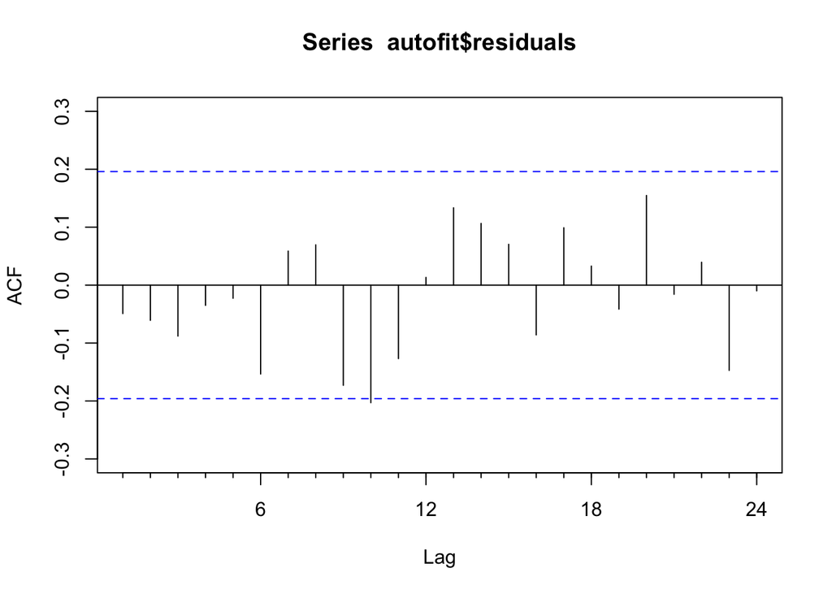

```r
#1. ACF
Acf(autofit$residuals)
```

```r
#2. Box test
Box.test(residuals(autofit), lag=20, type="Ljung")
```

```
##
##  Box-Ljung test
##
## data:  residuals(autofit)
## X-squared = 24.51, df = 20, p-value = 0.2208
```

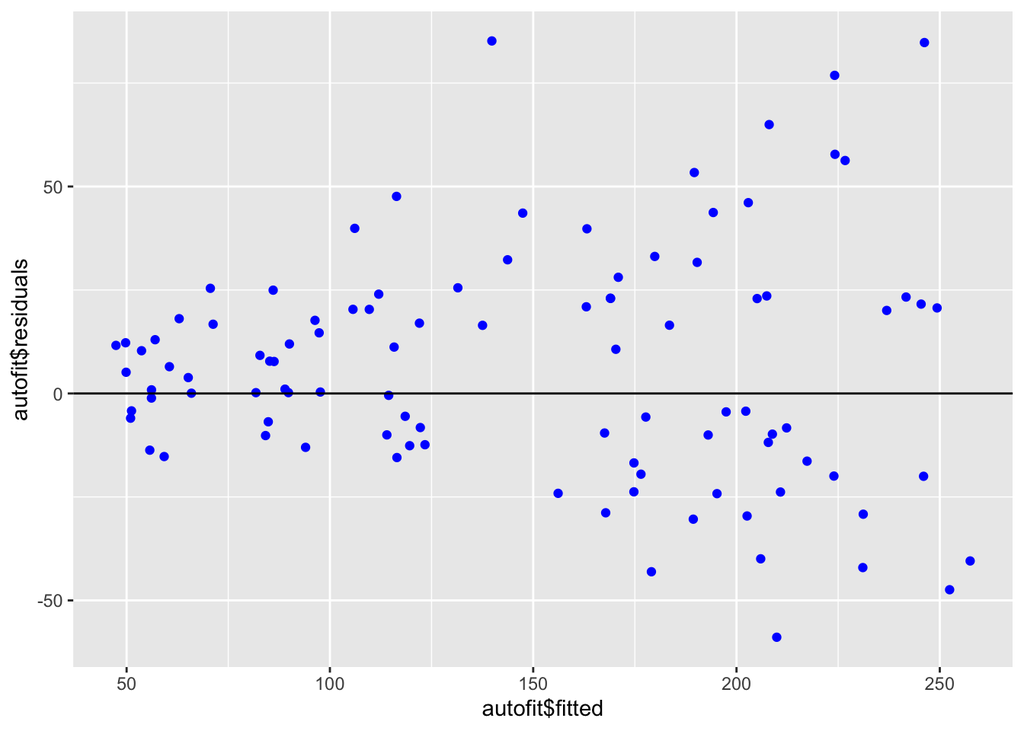

```r
#3. Residuals vs. Fitted
ggplot(data=data.frame(autofit$fitted,autofit$residuals),aes(x=autofit$fitted, y=autofit$residuals)) + geom_point(col="blue") + geom_hline(yintercept = 0)
```

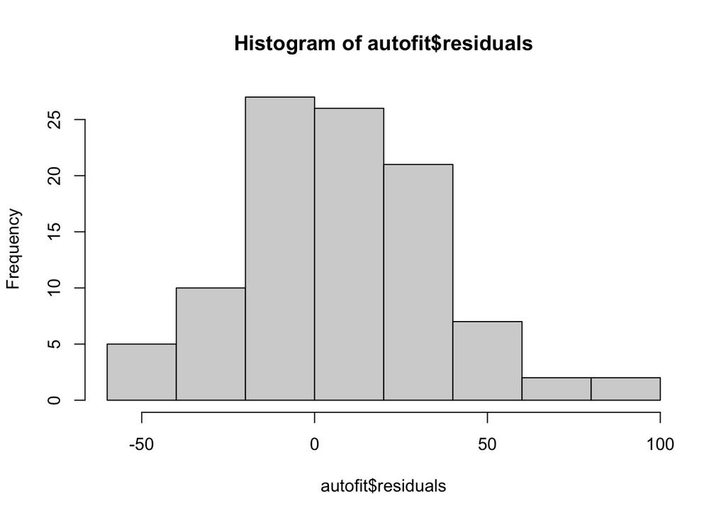

```r
#4. Histogram
hist(autofit$residuals)
```

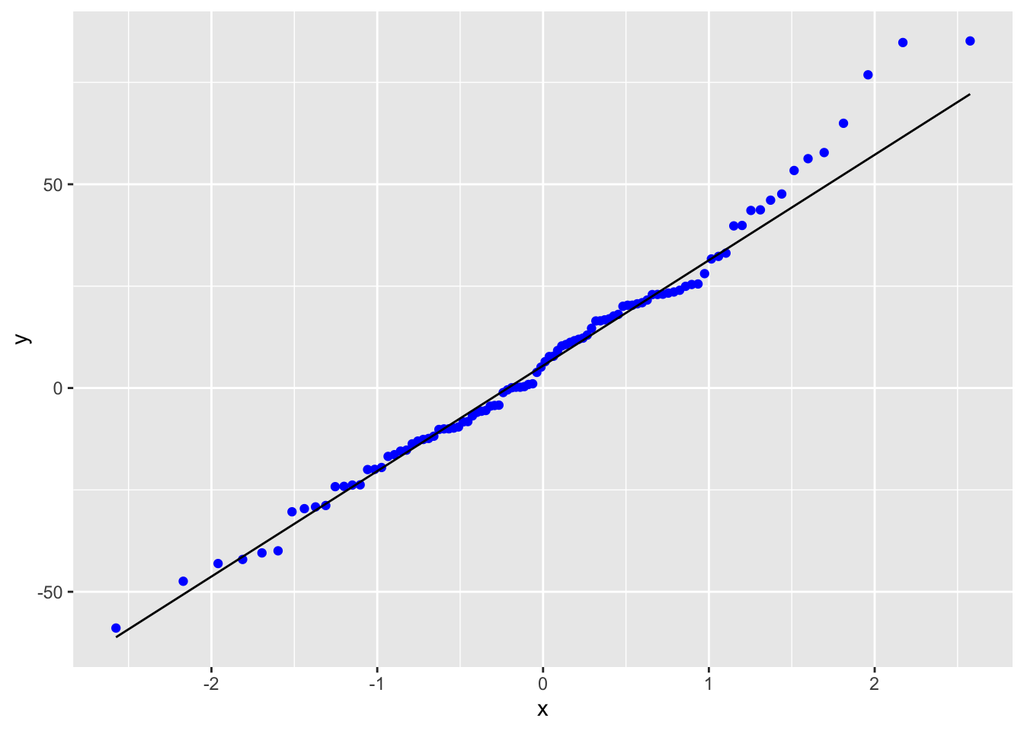

```r
#5. QQ plot
ggplot(autofit$residuals,aes(sample=autofit$residuals)) + stat_qq(color="blue") + stat_qq_line()
```

#### 3. Perform and Plot the forecast for the next five periods

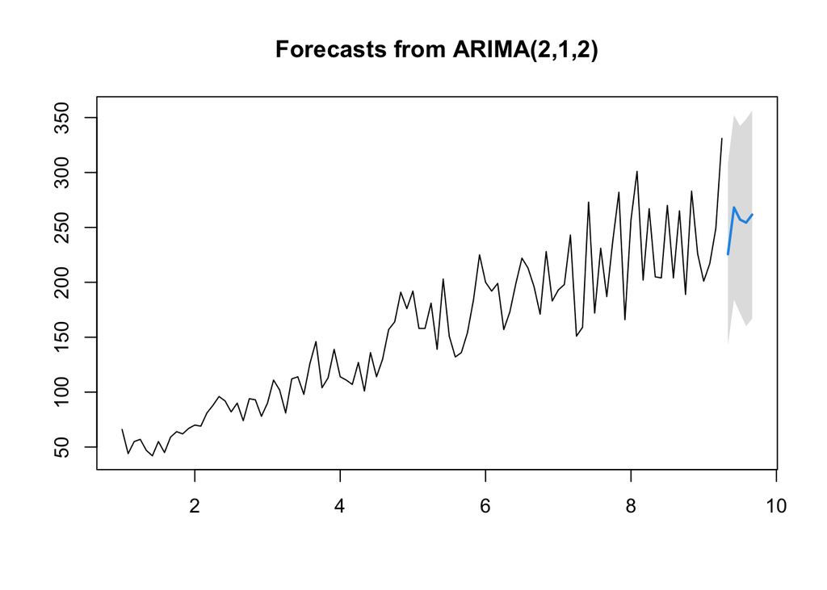

```r
arima_fc = forecast(autofit,h=5,level=c(99.5))
plot(arima_fc)
```

#### 4. Show the accuracy of your ARIMA model

```r
accuracy(autofit)
```

```
##                    ME     RMSE     MAE      MPE     MAPE      MASE        ACF1
## Training set 6.681614 28.69849 22.2282 2.661669 13.97698 0.5943731 -0.04908303
```

```r
summary(salests)
```

```
##    Min. 1st Qu.  Median    Mean 3rd Qu.    Max.
##    42.0    95.5   155.5   153.4   200.2   331.0
```

MASE is less than 1, so this model performs better than Naive model. By looking at the summary of the data, the Max value is 331 while Min is 42. RMSE is around 28, and considering the mean of the data, it can be considered small. MAPE is 13.9% and it’s in the acceptable range.

So I concluded that ARIMA performed quite accurately.

But just out of curiousity, I wanted to compare with other models that we learned in class.

#### Extra : other forecasts methods

```r
#Average
avg = meanf(salests,h=5)

#Moving Average
MA3 = ma(salests,order = 3)
MA3_fc = forecast(MA3, h=5)
```

```r
#Simple Smoothing
SES = HoltWinters(salests,beta=FALSE,gamma=FALSE)
SES_fc = forecast(SES, h=5)

#Holt Winters
HW = hw(salests,h=5)

#Plot the accuracy measures

a = accuracy(avg)
b = accuracy(MA3_fc)
c = accuracy(SES_fc)
d = accuracy(HW)
e = accuracy(autofit)

accuracymeasure = rbind(a,b,c,d,e)
rownames(accuracymeasure) = c('avg','MA','SES','HW','ARIMA')

accuracymeasure
```

```
##                  ME     RMSE       MAE         MPE      MAPE      MASE
## avg   -7.275958e-14 67.82261 57.271200 -28.0023559 52.673814 1.5314086
## MA     3.167299e-01 12.03495  8.642315  -0.1109273  5.357301 0.3188499
## SES    7.810173e+00 31.06652 24.129491   2.7351671 15.217962 0.6452128
## HW     1.339480e-01 26.01165 20.653352  -2.2381069 14.096662 0.5522622
## ARIMA  6.681614e+00 28.69849 22.228204   2.6616689 13.976979 0.5943731
##              ACF1
## avg    0.78094521
## MA    -0.08986128
## SES   -0.19487477
## HW    -0.09159884
## ARIMA -0.04908303
```

I expected ARIMA model to be the most accurate measure. However, by checking the accuracy measure, Moving Average turned out to be the most accurate one, which was surprising. I concluded that my dataset is not complicated enough for the ARIMA to perform the best, and that is why Moving Average, compartively simple method, performed the best with this data.